# ee

## Predicting death rate

```python
#!/usr/bin/python
# -*- coding:utf-8 -*-

import pprint
import pandas as pd
import seaborn as sns
import numpy as np
from scipy.optimize import minimize
from sklearn.preprocessing import *
from sklearn.ensemble import RandomForestClassifier, GradientBoostingClassifier
from sklearn.linear_model import LogisticRegression
from sklearn.metrics import *
from sklearn.model_selection import train_test_split
from sklearn.linear_model import LogisticRegression
from sklearn.ensemble import RandomForestClassifier
from sklearn.feature_selection import SelectKBest, f_classif, mutual_info_classif
from sklearn import svm
import os
import matplotlib.pyplot as plt
import numpy as np
from scipy.stats import norm
from scipy import stats
import warnings
import datetime
import scipy.sparse
from kmeans_smote import KMeansSMOTE
from numpy import *
import statsmodels.api as sm
warnings.filterwarnings('ignore')
# pd.set_option('display.height',1000)
pd.set_option('display.max_rows',500)
pd.set_option('display.max_columns',15)
pd.set_option('display.width',10000)
sns.set(style="darkgrid")
```

```python
col_types = {'expire_flag': 'category',
             'gender': 'category',
            'insurance': 'category',
             'ethnicity': 'category',
             'religion': 'category',
             'marital_status': 'category',
             'language': 'category',
             'admission_type': 'category',
             'admission_location': 'category'
             }
```

### 数据预处理

- 数据加载
  - 将不同变量转换成相应类型
    1. 因子型：性别，保险，种族，婚姻状态，死亡情况等
    2. 数值型（连续型）：chartevents, labevents, ouputevents, 年龄
- 数据清洗
  - 数据选取：每个病人进入icu后的前三次检测记录
  - 因子变量数值化：热编码
    - 离散特征的编码分为两种情况
      - 离散特征的取值之间没有大小的意义，比如color：[red,blue],那么就使用one-hot编码
      - 离散特征的取值有大小的意义，比如size:[X,XL,XXL],那么就使用数值的映射{X:1,XL:2,XXL:3}
  - 缺失值：
  - outlier：例如年龄出现300的异常值，同一将其转换成人工值80
  - 标准化
  - 降维：选取缺失比例小于50%的变量并对其进行互信息的计算，选取mutual_info_classif值最优的前30
    - 互信息，互信息度量 X 和 Y 共享的信息：它度量知道这两个变量其中一个，对另一个不确定度减少的程度。 参考：http://www.cnblogs.com/gatherstars/p/6004075.html
  - 样本不均衡：kmeans_smote http://www.cnki.com.cn/Article/CJFDTotal-SSJS201519026.htm
- 数据探索性分析
  - 数值型变量分析
  - 因子型变量分析
  - 变量相关性分析

```python
def plot_data(df, cols=None, type=None):
    if type == 1:
        fig = plt.figure()
#         plt.figure(figsize=(18, 9))
        df[cols].boxplot()
        plt.title("Numerical variables in this dataset", fontsize=20)
        plt.savefig('Numerical.png')
    elif type == 2:
        fig = plt.figure()
        # ax = fig.add_subplot(1,3,i)
        var = cols[0]
        data = pd.concat([df['expire_flag'], df[var]], axis=1)
        # print(df[var].value_count:())
        # f, ax = plt.subplots(figsize=(8, 6))
        sns.countplot(x=var, hue='expire_flag', data=data)
        # fig.axis(ymin=0, ymax=800000)
        plt.savefig('Categorical.png')
    elif type == 3:
        fig = plt.figure()
        data_corr = df[cols].corr()
        # data.fillna(value=np.nan, inplace=True)
        sns.heatmap(data_corr, xticklabels=1, yticklabels=1)
        plt.title('Correlation Matric')
        plt.savefig('Correlation_Matric.png')
    elif type == 4:
        fig = plt.figure()
        sns.pointplot(x='model', y='auc', data=df)
        plt.title('Model Comparison')
        plt.savefig('Model_Comparison.png')



def load_data(filename):
    df = pd.read_csv(filename, header = 0, sep=',', dtype=col_types)
    # print(df[['hadm_id','expire_flag','religion']].groupby(['religion','expire_flag']).count())

    # print('数据类型：\n', df.dtypes)

    ######################################### missing data
    features = pd.DataFrame({'a': df.apply(lambda x:sum(x.isnull())/df.shape[0])}).\
        sort_values('a')
    # print('missing value:')
    # print(features)
    features = features[features.a < 0.5]
    # print(features)
    df = df.loc[:, features.index]
    df.at[df[df['age'] > 200].index, 'age'] = 80
    # print(df[df['age']== 300].index)

    X = df.drop(['expire_flag','discharge_location','dob','admittime'], axis=1)
    y = df['expire_flag'].astype('category')

    ######################################### EDA
    full_cols = [
        '51279_itemid_min',
        '51277_itemid_min',
        '51265_itemid_min',
        '51250_itemid_min',
        'age',
        '51249_itemid_min',
        '51248_itemid_min',
        '51222_itemid_min',
        '51222_itemid_max',
        '51221_itemid_min',
        '51006_itemid_min',
        '50912_itemid_min'
    ]
    # print(list(col_types.keys()))
    # print(list(col_types.keys()).append('expire_flag'))
    plot_data(X, cols=['age', 'icu_no', '211_itemid_max'], type=1)
    plot_data(df, cols=['gender'], type=2)
    plot_data(df, cols=full_cols, type=3)

    ######################################### one-hot encoding, fill na, standard scale, feature selection
    X = pd.get_dummies(X).fillna(method='ffill').fillna(df.mean()).drop(['subject_id', 'hadm_id'], axis=1)
    names = X.columns
    X = pd.DataFrame(scale(X))
    X = StandardScaler().fit_transform(X)
    X = pd.DataFrame(X, columns=names)

    selectKBest = SelectKBest(mutual_info_classif, k=30)  # f_regression k特征值数量
    X = selectKBest.fit_transform(X, y)
    X = pd.DataFrame(X, columns=names[selectKBest.get_support()])
    # print('查看满足条件的列:\n', [i for i in enumerate(names[selectKBest.get_support()])])
    # print(X)

    ######################################### imbalance data
    [print('Class {} has {} instances before oversampling'.format(label, count))
     for label, count in zip(*np.unique(y, return_counts=True))]

    kmeans_smote = KMeansSMOTE(
        kmeans_args={
            'n_clusters': 3
        },
        smote_args={
            'k_neighbors': 10
        }
    )
    X_resampled, y_resampled = kmeans_smote.fit_sample(X, y)
    X =pd.DataFrame(X, columns=names[selectKBest.get_support()])

    [print('Class {} has {} instances after oversampling'.format(label, count))
     for label, count in zip(*np.unique(y_resampled, return_counts=True))]

    return X_resampled, y_resampled, X


def plot_feature_importance(model, feature_names):
    importance = model.feature_importances_
    std = np.std([tree.feature_importances_ for tree in model.estimators_], axis=0)
    indices = np.argsort(importance)[::-1]
    # Print the feature ranking
    print("Feature ranking:")

    for f in range(X.shape[1]):
        print("%d. %s (%f)" % (f + 1, feature_names[indices[f]], importance[indices[f]]))

    # Plot the feature importance of the forest
    plt.figure()
    plt.title("Feature importance")
    plt.bar(range(X.shape[1]), importance[indices],
            color="r", yerr=std[indices], align="center")
    plt.xticks(range(X.shape[1]), indices)
    plt.xlim([-1, X.shape[1]])
    plt.show()
```

### 建模及模型对比

- 训练集与测试集：6：4
- 模型
  - 逻辑回归: L2正则
    - 每个式子中前面那项是正则化项（Regularizer）（包含w的范数），后面那项是损失函数（loss function），参数C控制了两者在最终的损失函数中所占的比重。http://scikit-learn.org/stable/modules/linear_model.html#logistic-regression
  - 随机森林
  - 迭代集成GB

```
Class 0 has 350 instances before oversampling
Class 1 has 119 instances before oversampling
Class 0 has 350 instances after oversampling
Class 1 has 350 instances after oversampling
```

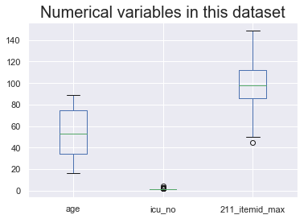

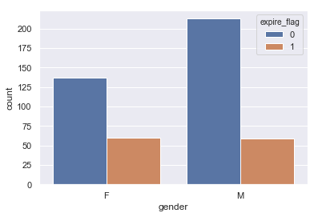

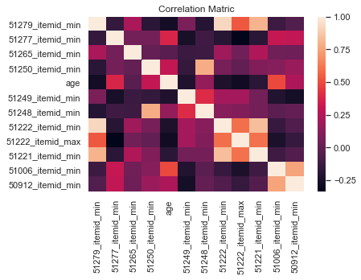

```python
if __name__ == '__main__':
    random.seed(5)
    X, y, X_pd = load_data('outV3.csv')
#     print(X_pd.head(3))
    x_train, x_test, y_train, y_test = train_test_split(X, y, random_state=1, train_size=0.6)
    y_train, y_test = y_train.astype(int), y_test.astype(int)
    # print(X)
    feature_names = X_pd.columns
    # print(feature_names)
```

```python
    # Logistic回归
    result = sm.Logit(y_train.ravel(), pd.DataFrame(x_train,columns=feature_names))
    result = result.fit()

    y_hat = result.predict(x_test)

    print('result.coef: ', result.summary())
#     print(np.exp(result.params))
```

```
Optimization terminated successfully.
         Current function value: 0.331255
         Iterations 10
result.coef:                             Logit Regression Results
==============================================================================
Dep. Variable:                      y   No. Observations:                  420
Model:                          Logit   Df Residuals:                      390
Method:                           MLE   Df Model:                           29
Date:                Tue, 28 Aug 2018   Pseudo R-squ.:                  0.5220
Time:                        12:05:28   Log-Likelihood:                -139.13
converged:                       True   LL-Null:                       -291.05
                                        LLR p-value:                 1.416e-47
===========================================================================================
                              coef    std err          z      P>|z|      [0.025      0.975]
-------------------------------------------------------------------------------------------
51277_itemid_max            0.2272      0.185      1.226      0.220      -0.136       0.591
51265_itemid_max            0.0222      0.142      0.156      0.876      -0.256       0.301
51249_itemid_min           -0.3837      0.204     -1.882      0.060      -0.783       0.016
51221_itemid_min            0.0015      0.246      0.006      0.995      -0.481       0.484
51221_itemid_max           -0.0420      0.243     -0.173      0.863      -0.518       0.434
51006_itemid_min            0.6422      0.701      0.915      0.360      -0.733       2.017
51006_itemid_max           -0.5342      0.704     -0.759      0.448      -1.914       0.846
age                         0.5566      0.304      1.831      0.067      -0.039       1.152
51237_itemid_min            0.4196      0.312      1.346      0.178      -0.192       1.031
50882_itemid_max           -0.4032      0.258     -1.561      0.118      -0.909       0.103
51274_itemid_max           -5.8722      7.398     -0.794      0.427     -20.373       8.628
51275_itemid_max            7.5888      1.852      4.098      0.000       3.959      11.219
51275_itemid_min           -0.0793      0.389     -0.204      0.839      -0.842       0.684
50868_itemid_min            0.2331      0.278      0.838      0.402      -0.312       0.778
50931_itemid_min           -0.0049      0.218     -0.022      0.982      -0.431       0.422
51237_itemid_max           -1.6871      7.477     -0.226      0.821     -16.341      12.967
50902_itemid_min            0.1886      0.204      0.925      0.355      -0.211       0.588
50893_itemid_max            0.3614      0.210      1.720      0.086      -0.051       0.773
50970_itemid_min            0.1603      0.219      0.732      0.464      -0.269       0.590
50809_itemid_max            0.3415      0.153      2.238      0.025       0.042       0.641
50821_itemid_min           -0.4319      0.219     -1.976      0.048      -0.860      -0.004
50802_itemid_min            0.8249      0.248      3.329      0.001       0.339       1.310
50806_itemid_max            0.1051      0.217      0.485      0.628      -0.320       0.530
677_itemid_min             -0.7553      0.388     -1.946      0.052      -1.516       0.005
51254_itemid_max            0.4212      0.157      2.690      0.007       0.114       0.728
insurance_Medicare          0.8498      0.365      2.326      0.020       0.134       1.566
insurance_Private          -0.0427      0.339     -0.126      0.900      -0.708       0.622
admission_type_ELECTIVE    25.5303      4.696      5.437      0.000      16.327      34.734
religion_JEWISH             0.1110      0.155      0.718      0.472      -0.192       0.414
marital_status_WIDOWED      0.0291      0.146      0.199      0.842      -0.257       0.315
===========================================================================================
```

```
Optimization terminated successfully.
         Current function value: 0.331255
         Iterations 10
Logistic
 accuracy： 0.8464285714285714 precision: 0.8389261744966443 recall： 0.8680555555555556 roc_auc:  0.9084456699346405

随机森林
 accuracy： 0.8464285714285714 precision: 0.8300653594771242 recall： 0.8819444444444444 roc_auc:  0.9112030228758169

GB
 accuracy： 0.8178571428571428 precision: 0.8163265306122449 recall： 0.8333333333333334 roc_auc:  0.8924121732026142

Feature ranking:
1. age (0.149613)
2. 51275_itemid_max (0.124945)
3. insurance_Private (0.121494)
4. 51249_itemid_min (0.107918)
5. 51277_itemid_max (0.103312)
6. insurance_Medicare (0.091300)
7. 677_itemid_min (0.081933)
8. 51221_itemid_max (0.055800)
9. 51237_itemid_max (0.049591)
10. 51274_itemid_max (0.026273)
11. 51006_itemid_max (0.025658)
12. 50809_itemid_max (0.017015)
13. 50970_itemid_min (0.014795)
14. 51221_itemid_min (0.009321)
15. 51275_itemid_min (0.008031)
16. 50882_itemid_max (0.006917)
17. marital_status_WIDOWED (0.002993)
18. 50893_itemid_max (0.002348)
19. 50806_itemid_max (0.000742)
20. 50868_itemid_min (0.000000)
21. religion_JEWISH (0.000000)
22. 50902_itemid_min (0.000000)
23. 51237_itemid_min (0.000000)
24. 50821_itemid_min (0.000000)
25. 50802_itemid_min (0.000000)
26. 51006_itemid_min (0.000000)
27. 51254_itemid_max (0.000000)
28. admission_type_ELECTIVE (0.000000)
29. 51265_itemid_max (0.000000)
30. 50931_itemid_min (0.000000)
```

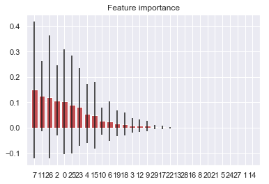

```
[0.9084456699346405, 0.9112030228758169, 0.8924121732026142]
```

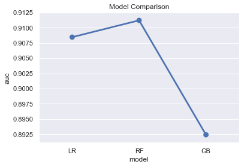

```python
    roc_lst = []
    # Logistic回归
    logit = sm.Logit(y_train.ravel(), pd.DataFrame(x_train,columns=feature_names))
    logit = logit.fit()
    y_score = logit.predict(x_test)

    lr = LogisticRegression(penalty='l2')
    lr.fit(x_train, y_train.ravel())
    # print(shape(x_train), shape(y_train.ravel()))
    y_hat = lr.predict(x_test)
#     y_score = lr.predict_proba(x_test)[:,1]

    roc_lst.append(roc_auc_score(y_test, y_score))
    print('Logistic\n','accuracy：', accuracy_score(y_test, y_hat),
          'precision:', precision_score(y_test, y_hat),
          'recall：', recall_score(y_test, y_hat),
          'roc_auc: ', roc_auc_score(y_test, y_score),
          '\n')
    # random forest
    RF = RandomForestClassifier(bootstrap=True, criterion='gini',
            max_depth=8, max_features='sqrt', min_impurity_decrease=0.0,
            min_samples_leaf=20, min_samples_split=100,
            min_weight_fraction_leaf=0.0, n_estimators=10, n_jobs=1,
            random_state=9, verbose=0)
    RF.fit(x_train, y_train.ravel())
    # print(RF.best_estimator_)
    y_hat = RF.predict(x_test)
    y_score = RF.predict_proba(x_test)[:, 1]
    roc_lst.append(roc_auc_score(y_test, y_score))
    print('随机森林\n', 'accuracy：', accuracy_score(y_test, y_hat),
          'precision:', precision_score(y_test, y_hat),
          'recall：', recall_score(y_test, y_hat),
          'roc_auc: ', roc_auc_score(y_test, y_score),
          '\n')

    grd = GradientBoostingClassifier(n_estimators=10)
    grd.fit(x_train, y_train.ravel())
    y_hat = grd.predict(x_test)
    y_score = grd.predict_proba(x_test)[:, 1]
    roc_lst.append(roc_auc_score(y_test, y_score))
    print('GB\n', 'accuracy：', accuracy_score(y_test, y_hat),
          'precision:', precision_score(y_test, y_hat),
          'recall：', recall_score(y_test, y_hat),
          'roc_auc: ', roc_auc_score(y_test, y_score),
          '\n')

    plot_feature_importance(RF, feature_names)

    print(roc_lst)
    auc_df = pd.DataFrame({'model': ['LR', 'RF', 'GB'],
                           'auc': roc_lst})
    plot_data(auc_df, type=4)
```